# Pronosticando los retornos de una acción

2018-01-11

En el [archivo de Excel](https://cecabrera.github.io/files/Datos.xlsx) hay información de precios desde el 10 de Abril de 2013 al 26 de Mayo de 2017 de la empresa “XYZ”. Me dí a la tarea de desarrollar un modelo estadístico que pronosticara si el precio de una acción sube o baja en función de su valor histórico y otras variables. Este análisis fue desarrollado en R, Markdown y GitHub y es hecho con propósitos investigativos. El código fuente pueden hallarlo en mi [reposotorio (carpeta)](https://github.com/cecabrera/stock) en GitHub.

# Tabla de contenidos

- Modelo de regresión logística
- Calculando la habilidad predictiva del modelo
- Análisis con modelos ARIMAX
- Análisis interactivo de 25 modelos
- Conclusiones
- Fuentes bibliográficas

Comenzamos cargando los paquetes a utilizar y los datos del archivo de Excel:

```
# install.packages(c("caTools", "tseries", "readxl", "data.table", "plotly"))
require(caTools)
require(tseries)
require(readxl)
require(data.table)
require(ggplot2)
require(corrplot)
library(ROCR)

d <- data.table(readxl::read_excel(path = "Datos.xlsx", sheet = 1))

# mostrar las primeras 6 filas de las primeras 7 columnas.
head(d[, .(fecha, open, high, low, close, volume)])
```

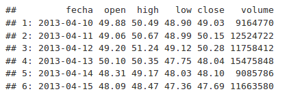

En la hoja `campos` del archivo de Excel se encuentra la descripción de cada una de las columnas de la variable `d`.

Graficamos el precio de cierre usando la librería `ggplot2`:

```
ggplot(data = d, aes(x = fecha, y = close)) + geom_line()
```

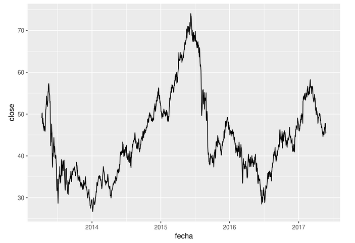

Antes de proceder a modelar los datos, los vamos a dividir en dos: un bloque de “training” para entrenar el modelo con el 80% de los datos y un bloque de “testing” para calcular el nivel de precisión de nuestro modelo con los datos más recientes.

```
train <- d[1:floor(nrow(d)*0.8),]
test <- d[(floor(nrow(d)*0.8)+1):nrow(d)]
```

## Modelo de regresión logística

Todas las variables en el archivo de Excel (a excepción de `fecha`) son numéricas. Mediante un modelo de regresión logística múltiple (Logit), calculamos las variables con mayor incidencia en la explicación de la variable `close_trend`.

```
model <- glm(close_trend ~ ., family = binomial(link = 'logit'), data = train[, -1, with = FALSE])
```

```
summary(model)
```

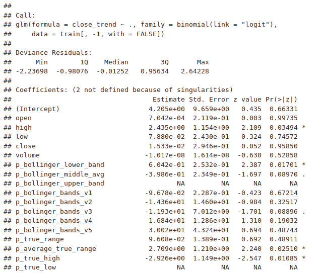

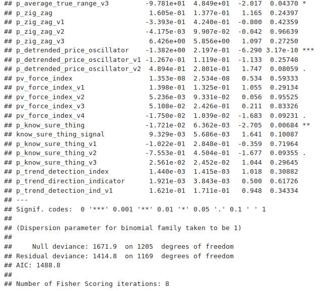

Todas estas variables fueron construidas basadas en el precio histórico; lo que compromete la calidad del modelo al violar el supuesto de no-multicolinealidad.

Mientras que no hay un equivalente al `R²` de los modelos de regresión lineal, el `R²` de McFadden puede ser usado para calcular el ajuste del modelo.

[output not shown]

## Calculando la habilidad predictiva del modelo

Es momento de calcular la precisión del modelo utilizando los datos de la variable `test` definida previamente. En vista que es un modelo Logit, el output son probabilidades por lo que usaremos una cota de 0.5 para determinar si el precio sube o bajo en los próximos días.

[output not shown]

Como último paso, calcularemos la *curva ROC* y el área bajo la curva (AUC) las cuales son medidas típicas de desempeño para clasificadores binarios.

El ROC es una curva creada para graficar la tasa de verdaderos positivos contra los falsos positivos en varias configuraciones, mientras que el AUC es el área bajo la curva de ROC. Como estándar en la academia, un modelo con buena habilidad predictiva debería estar cercano a 1 y lejos de 0.5 en el coeficiente de AUC.

```
p <- predict(model,newdata=test[, c(-1, -7), with = FALSE],type='response')
pr <- prediction(p, test$close_trend)
prf <- performance(pr, measure = "tpr", x.measure = "fpr")
plot(prf)
```

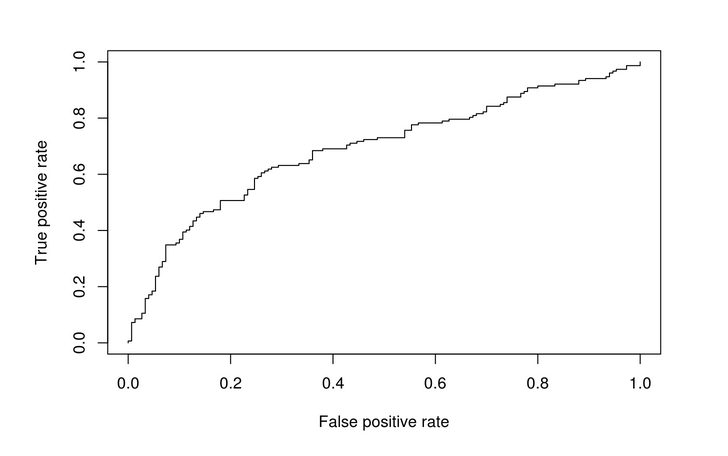

[output not shown]

## Análisis con modelos ARIMAX

```
d$returns <- c(NA, diff(d$open, lag = 1))

print(adf.test(d$close))
```

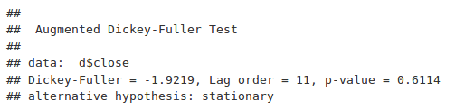

```
_ # Por resultado del Augmented Dickey-Fuller Test la serie no es estacional. A stationary time series means a time series without trend, one having a constant mean and variance over time, which makes it easy for predicting values. _

logical <- !is.na(d$returns)
print(adf.test(d[logical, returns]))
```

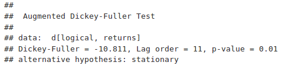

[output not shown]

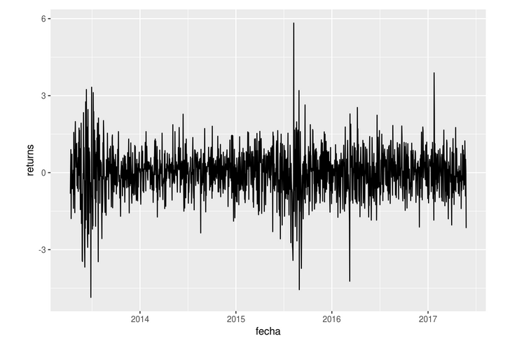

[output not shown]

*Fuente de información:* https://www.r-bloggers.com/forecasting-stock-returns-using-arima-model/

## Análisis interactivo de 25 modelos

*Código fuente:* https://github.com/daumann/r-stockPrediction/blob/master/findBestPrediction.r

_ En el ejemplo de este código, de los 25 modelos intentados, el óptimo fue uno de Redes Neuronales Artificiales. _

# Conclusiones

En la teoría, las variables del modelo de Regresión Logística ‘explicaron’ parte del comportamiento del precio de la acción. En la práctica, **los precios de las acciones responden a las expectativas que tiene el mercado en función de nueva información (como noticias)** y por ende, ninguna de las demás variables en la base de datos entran en esta categoría: dependen de información pasada. Hay que tener prudencia cuando se tomen decisiones de inversión teniendo en cuenta *únicamente* estas variables.

Finalmente, la precisión de un modelo está atada a su desempeño frente al “test” dataset y de sus métricas respecto a otros modelos. De ahí la importancia de cross validar con varias opciones.

# *Fuentes bibliográficas*

- https://www.quantinsti.com/blog/forecasting-stock-returns-using-arima-model/
- https://github.com/daumann/r-stockPrediction
- http://colorado.rstudio.com:3939/commodities-quandl-flexdb/
- http://www.sthda.com/english/wiki/correlation-matrix-a-quick-start-guide-to-analyze-format-and-visualize-a-correlation-matrix-using-r-software
- https://www.r-bloggers.com/how-to-perform-a-logistic-regression-in-r/
- http://www.statisticssolutions.com/assumptions-of-logistic-regression/